# Neural networks for billing code prediction

DRG stands for diagnosis related group. It is a payment multiplier of a standard rate the hospital receives for the care of a patient. It is based on the principal encounter diagnoses (an ICD 9 code) and the absence or presence of (major) complication or comorbidity (MCC/CC). Often times, codes are ensured to be specific so an encounter can be assigned a higher cost weight.

we will predict the DRG cost weight based on information occurring during the encounter. To do this, we will use neural networks for regression. After that, we will focus on ICD code prediction from the other events recorded during the encounter.

### Part1. Data Preprocessing

Treat each hadm_id (hosipitalization) as an example:

1. Construct a table with counts of each DRG.  
   Display the 10 DRGs with the highest cost weights. Display the 10 DRGs with the highest number of occurrences.

```r
library(tidyverse)
library(data.table)
library(keras)
library(pROC)

drg <- read_csv('drgevents.csv')
codeitem <- read_csv('d_codeditems.csv')
icd9 <- read_csv('icd9.csv')
medevent <- read_csv('medevents.csv')
meditem <- read_csv('d_meditems.csv')
icustay <- read_csv('icustay_detail.csv')
procedure <- read_csv('procedureevents.csv')
labitems <- read_csv('d_labitems.csv')
labevents <- fread('labevents.csv') %>% as_tibble()
```

```
##
Read 23.3% of 3740682 rows
Read 45.4% of 3740682 rows
Read 75.4% of 3740682 rows
Read 3740682 rows and 9 (of 9) columns from 0.206 GB file in 00:00:05
```

```r
# Construct a table with counts of each DRG
drg_tbl <- drg %>% group_by(itemid) %>%
  summarise(weight = mean(cost_weight),count = n()) %>%
  left_join(codeitem,by='itemid') %>%
  select(itemid,description,code,count,weight) %>%
  rename(drg_count = count)

# Display the 10 DRGs with the highest cost weights
drg_tbl %>%
  top_n(10,wt=weight) %>%
  arrange(-weight)
```

```
## # A tibble: 10 x 5
##    itemid                              description  code drg_count
##     <int>                                    <chr> <chr>     <int>
##  1  60776 TRACH W MV 96+ HRS OR PDX EXC FACE, MOUT   541        33
##  2  60775 ECMO OR TRACH W MV 96+HRS OR PDX EXC FAC   541        57
##  3  60007 ECMO OR TRACH W MV 96+ HRS OR PDX EXC FA   003         6
##  4  60169                         HEART TRANSPLANT   103         2
##  5  60703 TRACHEOSTOMY EXCEPT FOR FACE, MOUTH & NE   483       131
##  6  60755              HEART ASSIST SYSTEM IMPLANT   525         5
##  7  60778 TRACH W MV 96+ HRS OR PDX EXC FACE, MOUT   542        47
##  8  60009 TRACH W MV 96+ HRS OR PDX EXC FACE, MOUT   004         2
##  9  60011 LIVER TRANSPLANT W MCC OR INTESTINAL TRA   005         1
## 10  60699 LIVER TRANSPLANTS (ADULTS AND JUVENILES)   480        10
## # ... with 1 more variables: weight <dbl>
```

```r
# Display the 10 DRGs with the highest number of occurrences
drg_tbl %>%
  top_n(10,wt=drg_count) %>%
  arrange(-drg_count)
```

```
## # A tibble: 10 x 5
##    itemid                              description  code drg_count
##     <int>                                    <chr> <chr>     <int>
##  1  60614                       SEPTICEMIA AGE >17   416       277
##  2  60691 RESPIRATORY SYSTEM DIAGNOSIS WITH VENTIL   475       260
##  3  60024 INTRACRANIAL HEMORRHAGE & STROKE WITH IN   014       160
##  4  60272                  G.I. HEMORRHAGE WITH CC   174       160
##  5  60181     MAJOR CARDIOVASCULAR PROCEDURES W CC   110       141
##  6  60703 TRACHEOSTOMY EXCEPT FOR FACE, MOUTH & NE   483       131
##  7  60206                    HEART FAILURE & SHOCK   127       117
##  8  60490                            RENAL FAILURE   316        95
##  9  60681 EXTENSIVE O.R. PROCEDURE UNRELATED TO PR   468        87
## 10  60002                  CRANIOTOMY AGE >17 W CC   001        85
## # ... with 1 more variables: weight <dbl>
```

2. Use the diagnosis table with ICD 9 codes to create counts of diagnosis codes for every hadm_id. Display the 10 diagnoses with the highest number of occurrences.

```r
# some descriptions are in the wrong format, exclude them
des_cleaned = icd9$description[!str_detect(icd9$description,'\r$')]

icd9_tbl <- icd9 %>%
  group_by(hadm_id,code) %>%
  summarise(icd9.count = n()) %>%
  do(head(.,1)) %>% # memory issue: extract only one row in each group
  rename(icd9.code = code)
icd9_tbl_spread <- icd9_tbl %>% spread(icd9.code,icd9.count,fill=0)
icd9_tbl_spread$hadm_id <- as.character(icd9_tbl_spread$hadm_id)

# Display the 10 diagnoses with the highest number of occurrences.
icd9 %>%
  group_by(code) %>%
  summarise(n=n()) %>%
  arrange(-n) %>%
  top_n(10,wt=n) %>% left_join(icd9 %>% select(code,description) %>% unique(),by='code') %>%
  filter(description %in% des_cleaned)
```

```
## # A tibble: 10 x 3
##      code     n                                        description
##     <chr> <int>                                              <chr>
##  1  428.0  1845               CONGESTIVE HEART FAILURE UNSPECIFIED
##  2  401.9  1777                 UNSPECIFIED ESSENTIAL HYPERTENSION
##  3 427.31  1554                                ATRIAL FIBRILLATION
##  4  584.9  1133                    ACUTE RENAL FAILURE UNSPECIFIED
##  5 518.81  1124                          ACUTE RESPIRATORY FAILURE
##  6 414.01  1030 CORONARY ATHEROSCLEROSIS OF NATIVE CORONARY ARTERY
##  7 250.00   884  DIABETES MELLITUS WITHOUT COMPLICATION TYPE II OR
##  8  599.0   817         URINARY TRACT INFECTION SITE NOT SPECIFIED
##  9    486   630                     PNEUMONIA ORGANISM UNSPECIFIED
## 10    496   625 CHRONIC AIRWAY OBSTRUCTION NOT ELSEWHERE CLASSIFIE
```

3. Use the medications table to create counts of medications administered for every hadm_id. Display the names of the 10 medications with the highest number of occurrences

```r
med_tbl <- medevent %>% left_join(icustay,by=c('subject_id','icustay_id')) %>%
  select(subject_id,hadm_id,icustay_id,itemid) %>% unique() %>%
  group_by(hadm_id,itemid) %>%
  summarise(med.count = n()) %>%
  do(head(.,1)) %>%
  rename(med.id = itemid)
med_tbl_spread <- med_tbl %>% spread(med.id,med.count,fill=0)
med_tbl_spread$hadm_id <- as.character(med_tbl_spread$hadm_id)

# For same icustay_id,hadm_id,subject_id, if the same medication was given 2 times at different
# tiem, that occurrence of the medication will be '1'
medevent %>% left_join(icustay %>% select(subject_id,icustay_id,hadm_id),by=c('subject_id','icustay_id')) %>%
  select(subject_id,icustay_id,hadm_id,itemid) %>% unique() %>%
  group_by(itemid) %>%
  summarise(n=n()) %>%
  left_join(meditem,by='itemid') %>% arrange(-n)
```

```
## # A tibble: 59 x 3
##    itemid     n            label
##     <int> <int>            <chr>
##  1    131  1836         Propofol
##  2    120  1183       Levophed-k
##  3    128  1182  Neosynephrine-k
##  4     45  1128          Insulin
##  5     25  1045          Heparin
##  6    118   838         Fentanyl
##  7     43   815         Dopamine
##  8    126   730 Morphine Sulfate
##  9    121   704 Nitroglycerine-k
## 10    124   601        Midazolam
## # ... with 49 more rows
```

4. Use the procedures table to create counts of procedures for every hadm_id. Display the 10 procedure codes and descriptions with the highest number of occurrences.

```r
procedure_tbl <- procedure %>% group_by(hadm_id,itemid) %>%
  summarise(prcedr.count = n()) %>%
  arrange(hadm_id,itemid) %>%
  do(head(.,1)) %>%
  rename(prcedr.id = itemid)
procedure_tbl_spread <- procedure_tbl %>% spread(prcedr.id,prcedr.count,fill=0)
procedure_tbl_spread$hadm_id <- as.character(procedure_tbl_spread$hadm_id)

# Assumption: for the same subject_id,hadm_id, and item_id,
# if that procedure was given for more than one time, the occurrence of
# that procedure is still be one. (cause we want to see the occurrence of the procedure across different patient)
procedure %>%
  select(subject_id,hadm_id,itemid) %>%
  unique() %>%
  group_by(itemid) %>%
  summarise(n=n()) %>%
  left_join(codeitem,by='itemid') %>%
  select(itemid,description,n) %>% arrange(-n) %>% top_n(10)
```

```
## # A tibble: 10 x 3
##    itemid              description     n
##     <int>                    <chr> <int>
##  1 100574      VENOUS CATHETER NEC  1739
##  2 101749 INSERT ENDOTRACHEAL TUBE  1431
##  3 101834  PACKED CELL TRANSFUSION  1260
##  4 101780 EXT INFUS CONC NUTRITION  1111
##  5 101782 CONTINUOUS INVASIVE MECH  1061
##  6 101783 CONTINUOUS INVASIVE MECH   902
##  7 100572 ARTERIAL CATHETERIZATION   625
##  8 101843 PARENTERAL INFUS CONC NU   523
##  9 100622             HEMODIALYSIS   486
## 10 101648 CORONAR ARTERIOGR-2 CATH   481
```

5. Use the lab events table to create counts of lab events for every hadm_id. Display the 10 lab tuples with the highest number of occurrences.

```r
lab_tbl <- labevents %>%
  select(subject_id,hadm_id,itemid) %>%
  na.omit() %>%
  group_by(hadm_id,itemid) %>%
  summarise(lab.count = n()) %>%
  do(head(.,1)) %>%
  rename(lab.id = itemid)
lab_tbl_spread <- lab_tbl %>% spread(lab.id,lab.count,fill=0)
lab_tbl_spread$hadm_id <- as.character(lab_tbl_spread$hadm_id)

# counts of normal and abnormal events for all lab events
# treat NA as normal
labevents_noNA <- labevents %>%
  replace_na(list(flag = 'normal')) %>%  #replace na with 'normal'
  mutate(flag = if_else(flag=='delta','normal',flag)) #replace 'delta' with 'normal'
table(labevents_noNA$flag)
```

```
##
## abnormal   normal
##  1333311  2407371
```

```r
labevents_noNA %>%
  group_by(itemid) %>%
  summarise(n=n()) %>%
  arrange(-n) %>% left_join(labitems,by='itemid') %>%
  select(itemid,n,test_name) %>%
  top_n(10,wt=n)
```

```
## # A tibble: 10 x 3
##    itemid      n test_name
##     <int>  <int>     <chr>
##  1  50383 112607       HCT
##  2  50149 108267 POTASSIUM
##  3  50090 102217     CREAT
##  4  50159 101666    SODIUM
##  5  50177 101652    UREA N
##  6  50428 100044 PLT COUNT
##  7  50083  99215  CHLORIDE
##  8  50172  99184 TOTAL CO2
##  9  50068  97846 ANION GAP
## 10  50112  97499   GLUCOSE
```

Create a single table from the above tables in wide format

```r
# join tables into wide format by hadm_id
# transform data type of hadm_id in every tables into the same data type
drg_tbl <- drg %>% select(hadm_id,cost_weight)
drg_tbl$hadm_id <- as.character(drg_tbl$hadm_id)

# join tables
df <- drg_tbl %>% left_join(icd9_tbl_spread,by='hadm_id') %>% left_join(med_tbl_spread,by='hadm_id') %>%
  left_join(procedure_tbl_spread,by='hadm_id') %>% left_join(lab_tbl_spread,by='hadm_id')
df[is.na(df)] <- 0 # fill NA with 0

# transform the values by the function f(x) = log(1+x)
# don't have to transform hadm_id and cost_weight
collength <- length(colnames(df))
for (i in 3:collength){
  df[,i] = log(df[,i]+1)
}
```

Because the counts may vary considerably in magnitude, transform the values by the function f(x) = log(1+x). Create a train and test set with a 50%/50% split.

```r
# join tables into wide format by hadm_id
# transform data type of hadm_id in every tables into the same data type
drg_tbl <- drg %>% select(hadm_id,cost_weight)
drg_tbl$hadm_id <- as.character(drg_tbl$hadm_id)

# join tables
df <- drg_tbl %>% left_join(icd9_tbl_spread,by='hadm_id') %>% left_join(med_tbl_spread,by='hadm_id') %>%
  left_join(procedure_tbl_spread,by='hadm_id') %>% left_join(lab_tbl_spread,by='hadm_id')
df[is.na(df)] <- 0 # fill NA with 0

# transform the values by the function f(x) = log(1+x)
# don't have to transform hadm_id and cost_weight
collength <- length(colnames(df))
for (i in 3:collength){
  df[,i] = log(df[,i]+1)
}

itrain <- sample(seq(1:nrow(df)),nrow(df)*0.5)
x.train <- df[itrain,3:length(colnames(df))]  %>% as.matrix()
y.train <- df[itrain,2] %>% as.matrix()
x.test <- df[-itrain,3:length(colnames(df))] %>% as.matrix()
y.test <- df[-itrain,2] %>% as.matrix()
```

### Part2. Regression for cost weights

1. Modify the linear regression code to conduct L2 regularization (ridge regression). Instead of searching for the best setting of hyperparameter (which would normally do through CV or a tune set), in this case for simplicity just set it to 0.01.

loss function: mse (because it’s regression task)  
activation function: linear

```r
model = keras_model_sequential()
model %>%
  layer_dense(units = 1,
              activation = 'linear',
              input_shape = ncol(x.train)) %>%
  layer_activity_regularization(l2=0.01)
summary(model)
```

```
## ___________________________________________________________________________
## Layer (type)                     Output Shape                  Param #
## ===========================================================================
## dense_1 (Dense)                  (None, 1)                     986
## ___________________________________________________________________________
## activity_regularization_1 (Activ (None, 1)                     0
## ===========================================================================
## Total params: 986
## Trainable params: 986
## Non-trainable params: 0
## ___________________________________________________________________________
```

```r
model %>% compile(
  loss = c('mse'),
  optimizer = optimizer_nadam(clipnorm = 10),
  metrics = c('mse')
)
history =
  model %>% fit(x.train, y.train,
                epochs = 40,
                batch_size = 16,
                validation_split = 0.2, shuffle=T,
                verbose = 0
)
err <- model %>% evaluate(x.test,y.test)
```

```r
epochs_arr = c(20, 50 , 120)
batch_size_arr = c(10, 64, 128)
mse = list()

for(i in seq(1,length(epochs_arr))){
  for (j in seq(1,length(batch_size_arr))){
    model = keras_model_sequential()
    model %>%
      layer_dense(units = 1,
                  activation = 'linear',
                  input_shape = ncol(x.train)) %>%
      layer_activity_regularization(l2=0.01)
    model %>% compile(
      loss = c('mse'),
      optimizer = optimizer_nadam(clipnorm = 10),
      metrics = c('mse')
    )
    history =
      model %>% fit(x.train, y.train,
                    epochs = epochs_arr[i],
                    batch_size = batch_size_arr[j],
                    validation_split = 0.2, shuffle=T,
                    verbose = 0
      )
    mse[paste('epo_',i,'- bat_',j)] = history$metrics$val_mean_squared_error %>% tail(1)
  }
}

# When epoch = 120, batch = 10, mse is the smallest
model = keras_model_sequential()
model %>%
  layer_dense(units = 1,
              activation = 'linear',
              input_shape = ncol(x.train)) %>%
  layer_activity_regularization(l2=0.01)
summary(model)
```

```
## ___________________________________________________________________________
## Layer (type)                     Output Shape                  Param #
## ===========================================================================
## dense_11 (Dense)                 (None, 1)                     986
## ___________________________________________________________________________
## activity_regularization_11 (Acti (None, 1)                     0
## ===========================================================================
## Total params: 986
## Trainable params: 986
## Non-trainable params: 0
## ___________________________________________________________________________
```

```r
model %>% compile(
  loss = c('mse'),
  optimizer = optimizer_nadam(clipnorm = 10),
  metrics = c('mse')
)
history =
  model %>% fit(x.train, y.train,
                epochs = 120,
                batch_size = 10,
                validation_split = 0.2, shuffle=T ,
                verbose = 0
  )


# mean square error using eopch=120,batch_size=10 : 6.86
model %>% evaluate(x.test, y.test)
```

```
## $loss
## [1] 11.555
##
## $mean_squared_error
## [1] 6.78865
```

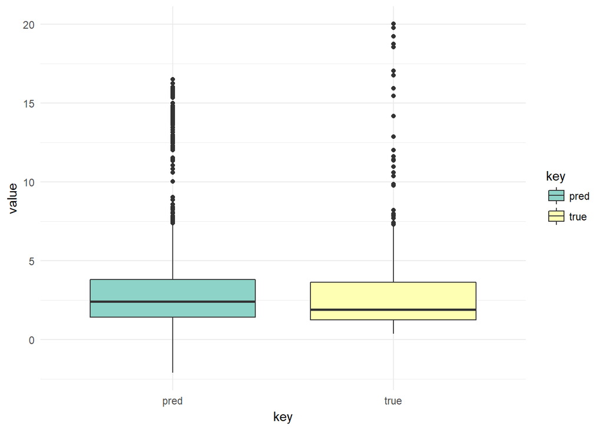

```r
result = model %>% predict(x.test) %>% as_tibble() %>%
  bind_cols(true = y.test) %>% rename(pred = V1)
result <- result %>% gather()

# boxplot
result %>%
  ggplot() +
  geom_boxplot(aes(x=key,y=value,fill=key)) +
  theme_minimal() +
  scale_fill_brewer(palette = 'Set3')
```

3. Create another model with 3 hidden layers of size 32 with the following activation functions: {tanh, leakyrelu, tanh}. Train the model and plot the cost weight predictions against the true cost weights.

```r
hidden_size = 32
model = keras_model_sequential()
model %>%
  layer_dense(units = hidden_size, activation = 'tanh',
              input_shape = c(ncol(x.train))) %>%
  layer_dense(units = hidden_size, activation = 'linear') %>%
  layer_activation_leaky_relu(alpha=0.1) %>%
  layer_dense(units = hidden_size, activation = 'tanh') %>%
  layer_dense(units = 1)
summary(model)
```

```
## ___________________________________________________________________________
## Layer (type)                     Output Shape                  Param #
## ===========================================================================
## dense_12 (Dense)                 (None, 32)                    31552
## ___________________________________________________________________________
## dense_13 (Dense)                 (None, 32)                    1056
## ___________________________________________________________________________
## leaky_re_lu_1 (LeakyReLU)        (None, 32)                    0
## ___________________________________________________________________________
## dense_14 (Dense)                 (None, 32)                    1056
## ___________________________________________________________________________
## dense_15 (Dense)                 (None, 1)                     33
## ===========================================================================
## Total params: 33,697
## Trainable params: 33,697
## Non-trainable params: 0
## ___________________________________________________________________________
```

```r
model %>% compile(
  loss = c('mse'),
  optimizer = optimizer_nadam(lr=1e-04,clipnorm = 10),
  metrics = c('mse')
)
history =
  model %>% fit(x.train, y.train,
                epochs = 50,
                batch_size = 10,
                validation_split = 0.2, shuffle=T,
                verbose = 0
  )
model %>% evaluate(x.test, y.test)
```

```
## $loss
## [1] 6.765606
##
## $mean_squared_error
## [1] 6.765606
```

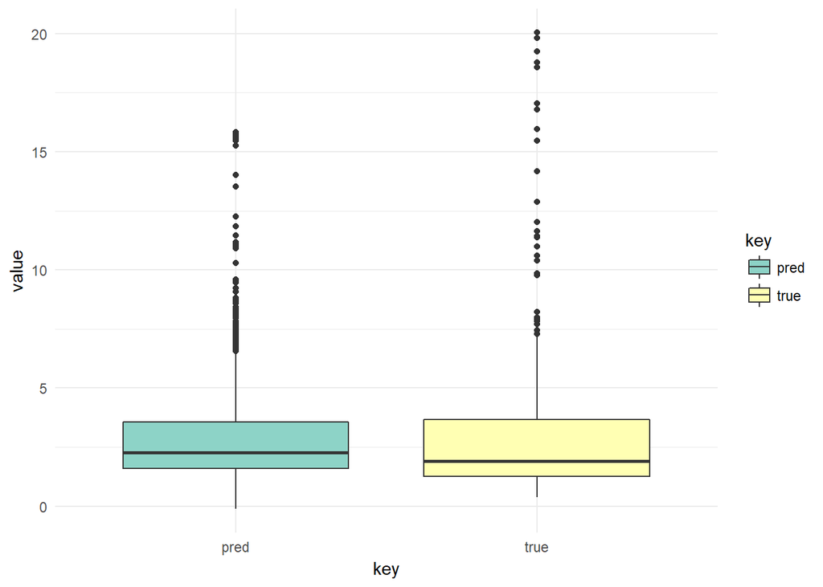

```r
result = model %>% predict(x.test) %>% as_tibble() %>%
  bind_cols(true = y.test) %>% rename(pred = V1)
result <- result %>% gather()
result %>%
  ggplot() +
  geom_boxplot(aes(x=key,y=value,fill=key)) +
  theme_minimal() +
  scale_fill_brewer(palette = 'Set3')
```

### Part 3: Multilabel classification of ICD codes

In practice, health care professionals work with billing coders to optimize the selection of diagnosis (ICD 9) codes to maximize payments received for the case provided. So while the above analysis gives a sense of our ability to predict cost weights (and thus reimbursement), we also want to select the appropriate corresponding diagnosis codes. We term this a multilabel classification problem because we want a vector binary outputs, one for each ICD 9 code.

1. Create a table from: medications, procedures, and lab events) for X matrix. For Y matrix, select the 100 most common ICD codes. Create a 50/50 train/test split. Report the 100 ICD codes and their descriptions.

```r
# medication table
med_tbl <- medevent %>% left_join(icustay,by=c('subject_id','icustay_id')) %>%
  select(hadm_id,itemid) %>%
  group_by(hadm_id,itemid) %>%
  summarise(med.count = n()) %>%
  rename(med.id = itemid)
med_tbl_spread <- med_tbl %>% spread(med.id,med.count,fill=0)
med_tbl_spread$hadm_id <- as.character(med_tbl_spread$hadm_id)

# procedure table
procedure_tbl <- procedure %>% group_by(hadm_id,itemid) %>%
  summarise(prcedr.count = n()) %>%
  arrange(hadm_id,itemid) %>%
  rename(prcedr.id = itemid)
procedure_tbl_spread <- procedure_tbl %>% spread(prcedr.id,prcedr.count,fill=0)
procedure_tbl_spread$hadm_id <- as.character(procedure_tbl_spread$hadm_id)

# lab table
lab_tbl <- labevents %>%
  select(hadm_id,itemid) %>%
  na.omit() %>%
  group_by(hadm_id,itemid) %>%
  summarise(lab.count = n()) %>%
  rename(lab.id = itemid)
lab_tbl_spread <- lab_tbl %>% spread(lab.id,lab.count,fill=0)
lab_tbl_spread$hadm_id <- as.character(lab_tbl_spread$hadm_id)

# display top 100 icd9 code
icd9_100 <- icd9 %>%
  group_by(code) %>%
  summarise(code.count = n()) %>%
  top_n(100,wt=code.count)

# For code with same description, keep the first one
code.desc <- icd9 %>% select(code,description) %>% unique() %>%
  group_by(code) %>%
  do(head(.,1)) %>% arrange(code)
# join table with counts and table with description
icd9_100 %>% left_join(code.desc,by='code') %>%
  select(code,code.count,description) %>% arrange(-code.count)
```

```
## # A tibble: 100 x 3
##      code code.count                                        description
##     <chr>      <int>                                              <chr>
##  1  428.0       1845               CONGESTIVE HEART FAILURE UNSPECIFIED
##  2  401.9       1777                 UNSPECIFIED ESSENTIAL HYPERTENSION
##  3 427.31       1554                                ATRIAL FIBRILLATION
##  4  584.9       1133                    ACUTE RENAL FAILURE UNSPECIFIED
##  5 518.81       1124       "RESPIRATORY FAILURE                     \r"
##  6 414.01       1030 CORONARY ATHEROSCLEROSIS OF NATIVE CORONARY ARTERY
##  7 250.00        884  DIABETES MELLITUS WITHOUT COMPLICATION TYPE II OR
##  8  599.0        817         URINARY TRACT INFECTION SITE NOT SPECIFIED
##  9    486        630                     PNEUMONIA ORGANISM UNSPECIFIED
## 10    496        625 CHRONIC AIRWAY OBSTRUCTION NOT ELSEWHERE CLASSIFIE
## # ... with 90 more rows
```

```r
# icd9 table (y matrix)
icd9_tbl <- icd9 %>%
  filter(code %in% icd9_100$code) %>%
  group_by(hadm_id,code) %>%
  summarise(code.count = n())

# binary output
icd9_tbl <- icd9_tbl %>%
  mutate(code.count = ifelse(code.count >=2, 1,code.count))
icd9_tbl_spread <- icd9_tbl %>% spread(code,code.count)
icd9_tbl_spread[is.na(icd9_tbl_spread)] <- 0

# join tables for x matrix
uniqueid <- icd9_tbl$hadm_id %>% unique() %>% as_data_frame() %>% rename(hadm_id = value)
uniqueid$hadm_id <- as.character(uniqueid$hadm_id)
df <- uniqueid %>% left_join(med_tbl_spread,by='hadm_id') %>%
  left_join(procedure_tbl_spread,by='hadm_id') %>%
  left_join(lab_tbl_spread,by='hadm_id')

# rescale the data
for (i in 2:ncol(df)){
  df[,i] = log(df[,i]+1)
}
df[is.na(df)] <- 0

# create train/test split
idx <- sample(1:nrow(df),nrow(df)*0.5)
xtrain <- df[idx,2:ncol(df)] %>% as.matrix()
ytrain <- icd9_tbl_spread[idx,2:ncol(icd9_tbl_spread)]%>% as.matrix()
xtest <- df[-idx,2:ncol(df)]%>% as.matrix()
ytest <- icd9_tbl_spread[-idx,2:ncol(icd9_tbl_spread)]%>% as.matrix()
```

2. Create a neural network that has at least two hidden layers.

```r
model = keras_model_sequential()
hidden_size = 30
model %>%
  layer_dense(units = hidden_size, activation = 'relu',
              input_shape = c(ncol(xtrain))) %>%
  layer_dense(units = hidden_size, activation = 'relu') %>%
  layer_dense(units = hidden_size, activation = 'relu') %>%
  layer_dense(units = 2, activation = 'sigmoid')
print(summary(model))
```

```
## ___________________________________________________________________________
## Layer (type)                     Output Shape                  Param #
## ===========================================================================
## dense_16 (Dense)                 (None, 30)                    48810
## ___________________________________________________________________________
## dense_17 (Dense)                 (None, 30)                    930
## ___________________________________________________________________________
## dense_18 (Dense)                 (None, 30)                    930
## ___________________________________________________________________________
## dense_19 (Dense)                 (None, 2)                     62
## ===========================================================================
## Total params: 50,732
## Trainable params: 50,732
## Non-trainable params: 0
## ___________________________________________________________________________
## NULL
```

3. Train the model.  
   loss = binary_crossentropy  
   final activation = softmax

```r
accu = list()
auc = list()

for(i in 1:100){
  model = keras_model_sequential()
  hidden_size = 30
  model %>%
    layer_dense(units = hidden_size, activation = 'relu',
                input_shape = c(ncol(xtrain))) %>%
    layer_dense(units = hidden_size, activation = 'relu') %>%
    layer_dense(units = hidden_size, activation = 'relu') %>%
    layer_dense(units = 2, activation = 'softmax')

  model %>% compile(
    loss = c('binary_crossentropy'),
    optimizer = 'rmsprop',
    metrics = c('accuracy')
  )
  history =
    model %>% fit(xtrain, to_categorical(ytrain[,i],2),
                  epochs = 20,
                  batch_size = 10,
                  validation_split = 0.2, shuffle=T,
                  verbose = 0
    )
  # compute the roc
  t = model %>%
    evaluate(xtest, to_categorical(ytest[,i],2))
  accu[paste('acc_',i)] = t$acc

  # compute the auc
  pred = model %>% predict(xtest)
  truth = ytest[,i]
  r <- roc(truth,pred[,1])
  auc[paste('auc_',i)] <- auc(r)
}
```

4. On the test set, compute the AUC for each ICD code. Plot a histogram of AUCs of the top 100 ICD9 codes.  
   average accuracy: 93%  
   average auc: 0.636

predicted best label:  
995.92:SYSTEMIC INFLAMMATORY RESPONSE SYNDROME DUE TO INF  
785.52:SEPTIC SHOCK  
431:INTRACEREBRAL HEMORRHAGE

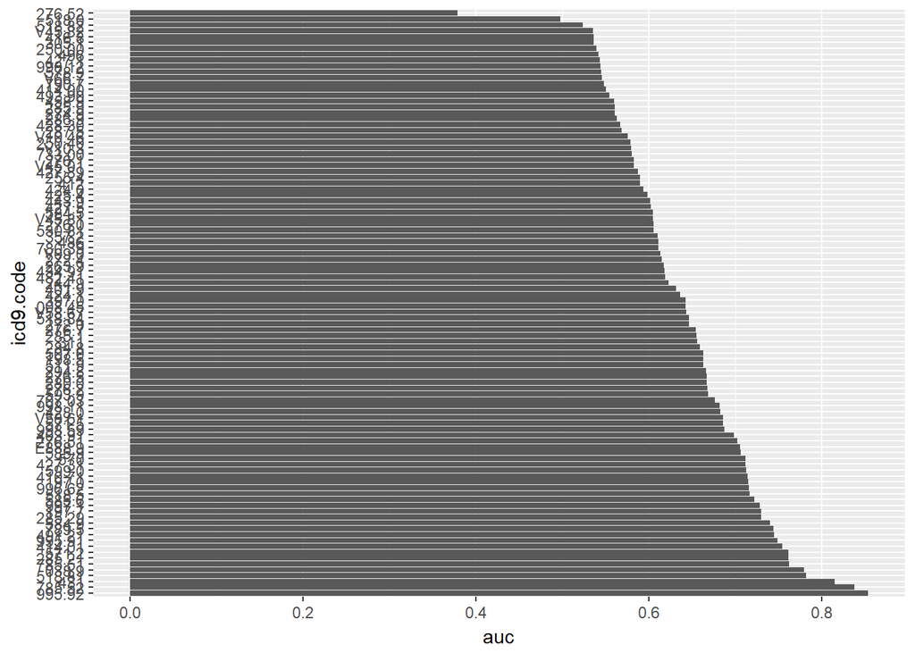

```r
auc_df <- auc %>% as.data.frame() %>% t() %>% as_tibble() %>% rownames_to_column()
icd9100 <- colnames(icd9_tbl_spread)[2:ncol(icd9_tbl_spread)] %>% as_tibble()
result <- cbind(icd9100,auc_df)
result$rowname <- NULL
colnames(result) <- c('icd9.code','auc')
result %>%
  ggplot(aes(x=reorder(icd9.code,-auc),y=auc)) +
  geom_histogram(stat='identity') +
  coord_flip() +
  labs(x = 'icd9.code')
```

```r
# look up the description
codelookup <- c(995.92,785.52,431, 998.59,255.4,998.12 )
i = icd9 %>%
  filter(code %in% codelookup) %>%
  select(code,description) %>%
  arrange(code) %>% unique()

accu = accu %>% unlist() %>% mean()
auc = auc %>% unlist() %>% mean()
```